# Survival of packages on CRAN

Xuan Fang

6/2020

# Background

There are a lot of R packages on CRAN, with the number growing exponentially over time. However, not all the packages stay there: they may be removed from the live version of CRAN by the author’s request or because they don’t work with the current version of R. All current and past packages are stored in the CRAN archive.

In recent years, many more people have been writing packages, and packages have tended to have more *dependencies* on other packages. This might be expected to lead to packages that don’t last as long.

The file `alldates.rda` contains a single data frame `all_dates`, with variables listed as follows:

| Variable | Description |
| --- | --- |
| pkg | the name of the package |
| cran_date | the date the current version was put on CRAN |
| first | the oldest date when a version was put into archive |
| latest | the most recent date when a version was put into archive |

Note: The dates are offsets from 1970/1/1

The file `snapshots.rda` contains two data frames:

a: the result of `available.packages()`, a matrix listing all available CRAN packages on 2020-6-2.

b: the result of `available.packages()` as it would have been on 2015-6-2, via the Microsoft CRAN Time Machine.

Our Tasks are:

1. Describe how the longevity of CRAN packages has changed over time
2. Describe how version number, dependencies, and license relate to the probability of a 2015 package surviving to 2020 (as a binary outcome)
3. Describe how dependencies, and license relate to the subsequent survival time of a package on CRAN in 2015

# Load datasets

```r
# Load the data
load(file = "alldates-1.rda")
load(file = "snapshots.rda")
```

# Task One

## Section 1: Data exploratory and data cleaning

### Pre-analysis exploratory: Examining `all_dates` dataset

```r
str(all_dates)
```

```
## 'data.frame':    18652 obs. of  4 variables:
##  $ pkg      : Factor w/ 18652 levels "A3","aaSEA","ABACUS",..: 1 2 3 4 5 6 7 8 9 10 ...
##  $ cran_date: num  16663 18209 18159 18072 16560 ...
##  $ first    : num  15743 18109 NA 16598 14887 ...
##  $ latest   : num  15791 18109 NA 17682 16263 ...
```

We notice there are ‘Inf’/‘-Inf’ values in the `first` and `latest` columns.

```r
summary(all_dates)
```

```
##        pkg          cran_date         first           latest
##  A3      :    1   Min.   :13222   Min.   :10143   Min.   : -Inf
##  aaSEA   :    1   1st Qu.:17269   1st Qu.:15427   1st Qu.:16495
##  ABACUS  :    1   Median :17961   Median :16645   Median :17475
##  abbyyR  :    1   Mean   :17672   Mean   :  Inf   Mean   : -Inf
##  abc     :    1   3rd Qu.:18298   3rd Qu.:17428   3rd Qu.:18024
##  abc.data:    1   Max.   :18414   Max.   :  Inf   Max.   :18412
##  (Other) :18646   NA's   :2939    NA's   :3757    NA's   :3757
```

```r
head(all_dates)
```

```
##        pkg cran_date first latest
## 1       A3     16663 15743  15791
## 2    aaSEA     18209 18109  18109
## 3   ABACUS     18159    NA     NA
## 4   abbyyR     18072 16598  17682
## 5      abc     16560 14887  16263
## 6 abc.data     16560    NA     NA
```

### Data cleaning

Remove records that have `first` = inf (and `latest` = -inf), which are implausible. But for `pkg = "sergeant"`, we set its `first` and `latest` columns to `NA` since it has value in `cran_date`.

```r
# Have a look at the records that have `first = inf` (and `latest = -inf`):
all_dates[is.infinite(all_dates$first), ]
```

```
##                   pkg cran_date first latest
## 12885        sergeant     18414   Inf   -Inf
## 15714      2020-05-14        NA   Inf   -Inf
## 15763             and        NA   Inf   -Inf
## 15788        Archived        NA   Inf   -Inf
## 15798              as        NA   Inf   -Inf
## 15879            been        NA   Inf   -Inf
## 16044           check        NA   Inf   -Inf
## 16143       corrected        NA   Inf   -Inf
## 16226          datasa        NA   Inf   -Inf
## 16269       depending        NA   Inf   -Inf
## 16274         despite        NA   Inf   -Inf
## 16641           given        NA   Inf   -Inf
## 16745            have        NA   Inf   -Inf
## 16833              in        NA   Inf   -Inf
## 16880              it        NA   Inf   -Inf
## 17005            long        NA   Inf   -Inf
## 17347         notice.        NA   Inf   -Inf
## 17394              on        NA   Inf   -Inf
## 17420        orphaned        NA   Inf   -Inf
## 17605        problems        NA   Inf   -Inf
## 17811      reminders.        NA   Inf   -Inf
## 18400           those        NA   Inf   -Inf
## 18409           time.        NA   Inf   -Inf
## 18588            were        NA   Inf   -Inf
## 18617 X-CRAN-Comment:        NA   Inf   -Inf
```

```r
# For pkg = "sergeant", we set first and latest to "NA":
all_dates$first[all_dates$pkg=="sergeant"] <- NA
all_dates$latest[all_dates$pkg=="sergeant"] <- NA
```

```r
# For the rest records, we just delete them, and now we get 18,628 records:
all_dates <- subset(all_dates, !is.infinite(all_dates$first))
summary(all_dates)
```

```
##        pkg          cran_date         first           latest
##  A3      :    1   Min.   :13222   Min.   :10143   Min.   :10143
##  aaSEA   :    1   1st Qu.:17269   1st Qu.:15423   1st Qu.:16502
##  ABACUS  :    1   Median :17961   Median :16643   Median :17478
##  abbyyR  :    1   Mean   :17672   Mean   :16263   Mean   :17151
##  abc     :    1   3rd Qu.:18298   3rd Qu.:17424   3rd Qu.:18025
##  abc.data:    1   Max.   :18414   Max.   :18411   Max.   :18412
##  (Other) :18622   NA's   :2915    NA's   :3758    NA's   :3758
```

```r
# If package is not 'alive', there will have an 'NA' in cran_date column. (2915 records)
summary(all_dates[is.na(all_dates$cran_date), ])
```

```
##            pkg         cran_date        first           latest
##  aaMI        :   1   Min.   : NA    Min.   :10143   Min.   :10143
##  ABCExtremes :   1   1st Qu.: NA    1st Qu.:14651   1st Qu.:15525
##  abemus      :   1   Median : NA    Median :15692   Median :16274
##  aBioMarVsuit:   1   Mean   :NaN    Mean   :15599   Mean   :16228
##  accuracy    :   1   3rd Qu.: NA    3rd Qu.:16863   3rd Qu.:17317
##  Ace         :   1   Max.   : NA    Max.   :18396   Max.   :18396
##  (Other)     :2909   NA's   :2915
```

#### Commentary:

There are 2,915 records that “cran_date” is ‘NA’, suggesting those packages are died (i.e. have been removed).

For those records that `cran_date` is not ‘NA’ (meaning it is alive) but the `first` and `latest` are both ‘NA’ means the version on CRAN is the first version, so there are no archived versions.

```r
# Take a look at those records (3758 records):
test <- subset(all_dates, is.na(first)&is.na(latest))
test$cran <- as.Date(test$cran_date)
summary(test)
```

```
##        pkg         cran_date         first          latest
##  ABACUS  :   1   Min.   :13222   Min.   : NA    Min.   : NA
##  abc.data:   1   1st Qu.:16900   1st Qu.: NA    1st Qu.: NA
##  ABC.RAP :   1   Median :17605   Median : NA    Median : NA
##  abcADM  :   1   Mean   :17411   Mean   :NaN    Mean   :NaN
##  abdiv   :   1   3rd Qu.:18110   3rd Qu.: NA    3rd Qu.: NA
##  abe     :   1   Max.   :18414   Max.   : NA    Max.   : NA
##  (Other) :3752                   NA's   :3758   NA's   :3758
##       cran
##  Min.   :2006-03-15
##  1st Qu.:2016-04-09
##  Median :2018-03-15
##  Mean   :2017-09-01
##  3rd Qu.:2019-08-02
##  Max.   :2020-06-01
##
```

### Adding new variables:

First, we want to create a new variable `end_date` that is the removal date for packages that are removed, or presumably at the time the data were downloaded, which is 2020-6-2. If the package is still alive, it is censored either when the data was retrieved or at the date the current version appeared on CRAN. There are arguments in favour of either choice. Nevertheless, we decide to set the `end_date` as the date were downloaded.

```r
end_date_num <- ifelse(is.na(all_dates$cran_date), all_dates$latest, as.Date("2020-6-2"))
all_dates$end_date <- end_date_num
summary(all_dates)
```

```
##        pkg          cran_date         first           latest
##  A3      :    1   Min.   :13222   Min.   :10143   Min.   :10143
##  aaSEA   :    1   1st Qu.:17269   1st Qu.:15423   1st Qu.:16502
##  ABACUS  :    1   Median :17961   Median :16643   Median :17478
##  abbyyR  :    1   Mean   :17672   Mean   :16263   Mean   :17151
##  abc     :    1   3rd Qu.:18298   3rd Qu.:17424   3rd Qu.:18025
##  abc.data:    1   Max.   :18414   Max.   :18411   Max.   :18412
##  (Other) :18622   NA's   :2915    NA's   :3758    NA's   :3758
##     end_date
##  Min.   :10143
##  1st Qu.:18415
##  Median :18415
##  Mean   :18073
##  3rd Qu.:18415
##  Max.   :18415
##
```

Then, we create a new variable `removed` as an event(removal) indicator.

```r
all_dates$removed<- is.na(all_dates$cran_date)
```

## Section 2: Data analysis

The biggest problem is that we don’t have the date the package first appeared on CRAN unless the current version is the first version: `first` is the first date the package was archived, which is either the date of the second version or is when the package was removed from CRAN, whichever is earlier. We’re going to use `first` as the start date because it’s what we’ve got and it isn’t bad.

We’re looking at survival from `first` arrival on CRAN, which is time zero, and the end of observation time is `end_date`-`first`. The event indicator is `is.na(cran_date)`, which we created previously as `removed``.

```r
summary(as.Date(all_dates$first))
```

```
##         Min.      1st Qu.       Median         Mean      3rd Qu.         Max.
## "1997-10-09" "2012-03-23" "2015-07-27" "2014-07-11" "2017-09-15" "2020-05-29"
##         NA's
##       "3758"
```

Fit a Cox model by defining a `start_period` variable:

```r
cut_points<- as.Date(c("1996-1-1","2001-1-1","2006-1-1","2011-1-1","2016-1-1","2020-6-3"))
all_dates$start_period <- with(all_dates, cut(as.Date(first), cut_points))
coxph(Surv(end_date-first, removed)~start_period, data=all_dates)
```

```
## Call:
## coxph(formula = Surv(end_date - first, removed) ~ start_period,
##     data = all_dates)
##
##                             coef exp(coef)  se(coef)      z        p
## start_period2001-01-01 -0.163520  0.849149  0.179085 -0.913 0.361196
## start_period2006-01-01  0.006469  1.006490  0.168472  0.038 0.969368
## start_period2011-01-01 -0.156825  0.854854  0.167068 -0.939 0.347889
## start_period2016-01-01 -0.560433  0.570962  0.169069 -3.315 0.000917
##
## Likelihood ratio test=122.6  on 4 df, p=< 2.2e-16
## n= 14870, number of events= 2915
##    (3758 observations deleted due to missingness)
```

Visualization:

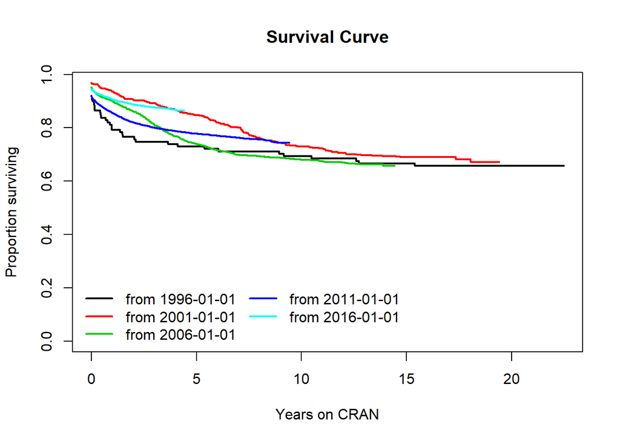

```r
cran_periods<-survfit(Surv(end_date-first, removed)~start_period, data=all_dates)
plot(cran_periods, col = 1:5, lwd = 2, xscale = 365,
     xlab = "Years on CRAN", ylab = "Proportion surviving", main = "Survival Curve")
legend("bottomleft", bty = "n", ncol = 2, lwd = 2, col = 1:5, legend=paste("from",cut_points)[-6])
```